# NON-S-BANDIT-HYSMAX001

```r
rm(list=ls())
require(Matrix)
```

1st, we build a bandit class, and a method for pulling the bandits lever to return some reward. Each bandit has its own mean and standard deviation to control its reward. I like to think of each lever as its own bandit.

```r
bandit <- setClass("bandit", slots = representation(mu = "numeric",st =  "numeric") )
b1 <- bandit(mu = 1, st = 3)
# b1@mu # use the at symbol to access the classes attributes.
# b1@st
pull_lever <- function(mu, st){
# Shell for setMethod
}
setMethod("pull_lever", "bandit",
          function(mu,st){
            # print(mu@st)  # why tf does this work??
            # print(mu@mu)
            # s <- pull_lever(mu,st)
            return(rnorm(1,mean = mu@mu, sd = mu@st))
          })
pull_lever(b1)
```

```
[1] -0.4275246
```

Now that we have our bandit class, we create 5 bandits, and the Q table, to learn optimal play

```r
sd <- 0.154
b1 <- bandit(mu=1,st=sd)
b2 <- bandit(mu=2,st=sd)
b3 <- bandit(mu=3,st=sd)
b4 <- bandit(mu=4,st=sd)
b5 <- bandit(mu=5,st=sd)
bandits <- c(b1,b2,b3,b4,b5)
```

From Sutton and Barto page 38.

Making the bandits non stationary, and comparing $Q_{k+1}=Q_{k}+\frac{1}{k}\left[R_{k}-Q_{k}\right]$ to $Q_{k+1}=Q_{k}+\alpha\left[R_{k}-Q_{k}\right]$. Here the difference is $\text {StepSize}$ in $\text { NewEstimate } \leftarrow \text { OldEstimate }+\text { StepSize [Target- OldEstimate] }$. The latter, instead of taking the average reward to update our $Q$ table, we are assigning higher weightings to more recent rewards, in an attempt to deal with the non-stationarity. (learn how to write you plum)

```r
# There is only one state in the n-arm bandit scenario, and there are n actions.
# Action 1 pulls the lever on bandit b1, ..., Action 5 pulls the lever on b5.
t <- 400L
n <- 70L
epsilons <- c(0.001, 0.1, 0.01)
Average_Returns <- matrix(0, ncol = t, nrow = 3)
# =============== Stationary Time Series ==============
ts <- matrix(nrow = length(bandits), ncol = t)
for(spin in 1:t){
  for(ban in 1:length(bandits)){
    ts[ban,spin] <- pull_lever(bandits[[ban]])
  }
}
# =====================================================

# The 1/k method, where k is the number of times that some action has been used
for (run in 1:n){


  Q <- rep(0.2, 5) # init Q table (only 1 state, with 5 actions)
  Q <- rbind(Q,Q,Q) # 3 rows, one for each epsilon
  R <- matrix(0,nrow=3,ncol=t)
  k <- rep(1,5)
  k <- rbind(k,k,k)


  for (e in 1:length(epsilons)){
    for(i in 1:t){
      if (epsilons[e] < runif(1) ){
        action <- which.max(Q[e,])
      }else{
        action <- sample(1:5,1)
      }
      k[action] <- k[action]+1 # keeping track of how many times each action is used
      R[e,i] <- ts[action,i]
      Q[e,action] <- Q[e,action] + (1/(k[e,action])) * (R[e,i] - Q[e,action])
    }
  }
  Average_Returns <- (Average_Returns + R) / 2
}
plot(Average_Returns[2,], type = "l", col="green", ylim = c(0, max(Average_Returns)))
lines(Average_Returns[3,], col="red")
```

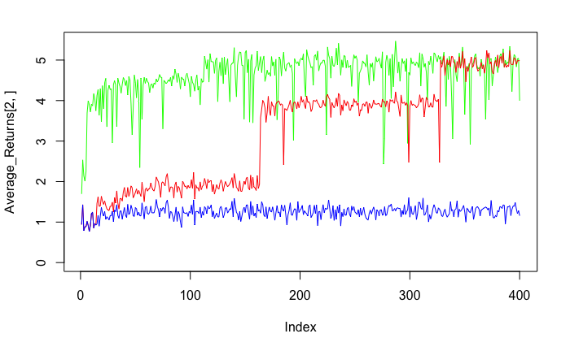

```r
lines(Average_Returns[1,], col="blue")
```

Introducing Non-Stationarity

```r
t <- 400L
n <- 70L
epsilons <- c(0, 0.1, 0.01)
Average_Returns <- matrix(0, ncol = t, nrow = 3)
sd <- 0.154
b1 <- bandit(mu=1,st=sd)
b2 <- bandit(mu=2,st=sd)
b3 <- bandit(mu=3,st=sd)
b4 <- bandit(mu=4,st=sd)
b5 <- bandit(mu=5,st=sd)
bandits <- c(b1,b2,b3,b4,b5)
# ============= NON-Stationary Time Series ============
ts <- matrix(nrow = length(bandits), ncol = t)
for(spin in 1:t){
  for(ban in 1:length(bandits)){
    ts[ban,spin] <- pull_lever(bandits[[ban]])

  }
  if(spin %% round(t/4) == 1){ # introducing non-stationarity
    b5@mu <- b5@mu-1
    b3@mu <- b3@mu+0.5
    b4@mu <- b4@mu-0.5

    bandits <- c(b1,b2,b3,b4,b5)
  }
}
# =====================================================
# The 1/k method, where k is the number of times that some action has been used
for (run in 1:n){


  Q <- rep(0.2, 5) # init Q table (only 1 state, with 5 actions)
  Q <- rbind(Q,Q,Q) # 3 rows, one for each epsilon
  R <- matrix(0,nrow=3,ncol=t)
  k <- rep(1,5)
  k <- rbind(k,k,k)



  for (e in 1:length(epsilons)){


    for(i in 1:t){
      if (epsilons[e] < runif(1) ){
        action <- which.max(Q[e,])
      }else{
        action <- sample(1:5,1)
      }
      k[action] <- k[action]+1 # keeping track of how many times each action is used
      R[e,i] <- ts[action,i]
      Q[e,action] <- Q[e,action] + (1/(k[e,action])) * (R[e,i] - Q[e,action])

    }
  }
  Average_Returns <- (Average_Returns + R) / 2
}
plot(Average_Returns[2,], type = "l", col="green", ylim = c(0, max(Average_Returns)))
lines(Average_Returns[3,], col="red")
```

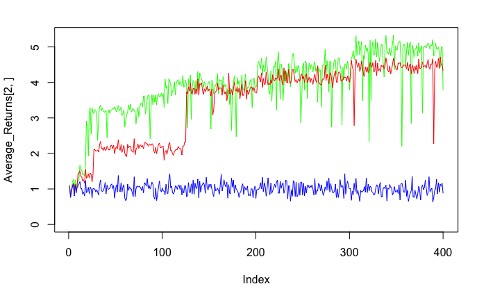

```r
lines(Average_Returns[1,], col="blue")
```

```r
Average_Returns <- matrix(0, ncol = t, nrow = 3)
# The ALPHA method:
for (run in 1:n){


  Q <- rep(0.2, 5) # init Q table (only 1 state, with 5 actions)
  Q <- rbind(Q,Q,Q) # 3 rows, one for each epsilon
  R <- matrix(0,nrow=3,ncol=t)
  k <- rep(1,5)
  k <- rbind(k,k,k)
  alpha <- 0.4



  for (e in 1:length(epsilons)){

    for(i in 1:t){
      if (epsilons[e] < runif(1) ){
        action <- which.max(Q[e,])
      }else{
        action <- sample(1:5,1)
      }
      k[action] <- k[action]+1 # keeping track of how many times each action is used
      R[e,i] <- ts[action,i]
      Q[e,action] <- Q[e,action] + alpha * (R[e,i] - Q[e,action])
    }
  }
  Average_Returns <- (Average_Returns + R) / 2
}
plot(Average_Returns[2,], type = "l", col="green", ylim = c(0, max(Average_Returns)))
lines(Average_Returns[3,], col="red")
```

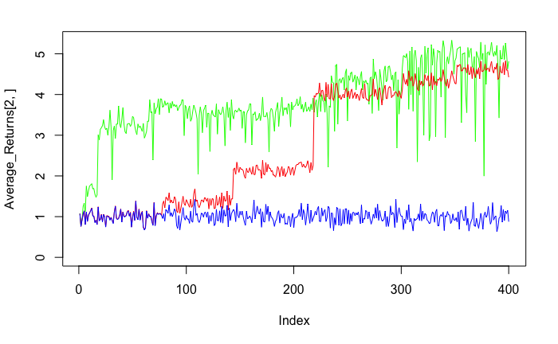

```r
lines(Average_Returns[1,], col="blue")
```